# Homework 5

Patrick Strzalkowski

18/03/2020

```r
library(rpart)
library(rpart.plot)
setwd("~/Laurier/Advanced Biostatistics/Homework 5")

crimedata=read.csv("crimedata.csv")
```

```r
#Summary of dataset
summary(crimedata)
```

```
##    CrimeRate         Youth          Southern        Education
##  Min.   : 45.5   Min.   :119.0   Min.   :0.0000   Min.   :10.00
##  1st Qu.: 82.7   1st Qu.:130.0   1st Qu.:0.0000   1st Qu.:11.55
##  Median :103.0   Median :136.0   Median :0.0000   Median :12.40
##  Mean   :102.8   Mean   :138.6   Mean   :0.3404   Mean   :12.39
##  3rd Qu.:120.7   3rd Qu.:146.0   3rd Qu.:1.0000   3rd Qu.:13.20
##  Max.   :161.8   Max.   :177.0   Max.   :1.0000   Max.   :15.10
##  ExpenditureYear  LabourForce        Males          MoreMales
##  Min.   : 45.0   Min.   :480.0   Min.   : 934.0   Min.   :0.0000
##  1st Qu.: 62.5   1st Qu.:530.5   1st Qu.: 964.5   1st Qu.:0.0000
##  Median : 78.0   Median :560.0   Median : 977.0   Median :0.0000
##  Mean   : 85.0   Mean   :561.2   Mean   : 983.0   Mean   :0.1915
##  3rd Qu.:104.5   3rd Qu.:593.0   3rd Qu.: 992.0   3rd Qu.:0.0000
##  Max.   :166.0   Max.   :641.0   Max.   :1071.0   Max.   :1.0000
##    StateSize      YouthUnemployment MatureUnemployment HighYouthUnemploy
##  Min.   :  3.00   Min.   : 70.00    Min.   :20.00      Min.   :0.0000
##  1st Qu.: 10.00   1st Qu.: 80.50    1st Qu.:27.50      1st Qu.:0.0000
##  Median : 25.00   Median : 92.00    Median :34.00      Median :0.0000
##  Mean   : 36.62   Mean   : 95.47    Mean   :33.98      Mean   :0.3191
##  3rd Qu.: 41.50   3rd Qu.:104.00    3rd Qu.:38.50      3rd Qu.:1.0000
##  Max.   :168.00   Max.   :142.00    Max.   :58.00      Max.   :1.0000
##       Wage         BelowWage
##  Min.   :288.0   Min.   :126.0
##  1st Qu.:459.5   1st Qu.:165.5
##  Median :537.0   Median :176.0
##  Mean   :525.4   Mean   :194.0
##  3rd Qu.:591.5   3rd Qu.:227.5
##  Max.   :689.0   Max.   :276.0
```

# variables used: ExpenditureYear, StateSize, BelowWage, Education, YouthUnemployment, MatureUnemployment

```r
# Q2

#Building regression tree with training set
m.rpart <- rpart(CrimeRate ~  ExpenditureYear + StateSize + Education + BelowWage + YouthUnemployment + MatureUnemployment, data = crimedata)

# Q3

#Print summary of tree
summary(m.rpart)
```

```
## Call:
## rpart(formula = CrimeRate ~ ExpenditureYear + StateSize + Education +
##     BelowWage + YouthUnemployment + MatureUnemployment, data = crimedata)
##   n= 47
##
##           CP nsplit rel error    xerror      xstd
## 1 0.39334682      0 1.0000000 1.0527342 0.1802895
## 2 0.09454168      1 0.6066532 0.7224793 0.1250719
## 3 0.06050197      2 0.5121115 0.7399052 0.1554951
## 4 0.01000000      3 0.4516095 0.7478033 0.1581556
##
## Variable importance
##    ExpenditureYear          BelowWage          StateSize MatureUnemployment
##                 33                 17                 17                 12
##  YouthUnemployment          Education
##                 12                 10
##
## Node number 1: 47 observations,    complexity param=0.3933468
##   mean=102.8085, MSE=817.0587
##   left son=2 (23 obs) right son=3 (24 obs)
##   Primary splits:
##       ExpenditureYear    < 76.5  to the left,  improve=0.39334680, (0 missing)
##       StateSize          < 48.5  to the left,  improve=0.11935310, (0 missing)
##       MatureUnemployment < 27.5  to the left,  improve=0.10060020, (0 missing)
##       BelowWage          < 248   to the right, improve=0.06924067, (0 missing)
##       Education          < 13.65 to the left,  improve=0.04244413, (0 missing)
##   Surrogate splits:
##       BelowWage          < 171.5 to the right, agree=0.745, adj=0.478, (0 split)
##       MatureUnemployment < 28.5  to the left,  agree=0.702, adj=0.391, (0 split)
##       StateSize          < 48.5  to the left,  agree=0.681, adj=0.348, (0 split)
##       Education          < 11.55 to the left,  agree=0.638, adj=0.261, (0 split)
##       YouthUnemployment  < 77.5  to the left,  agree=0.638, adj=0.261, (0 split)
##
## Node number 2: 23 observations,    complexity param=0.09454168
##   mean=84.49565, MSE=375.2891
##   left son=4 (12 obs) right son=5 (11 obs)
##   Primary splits:
##       StateSize          < 22.5  to the left,  improve=0.42061100, (0 missing)
##       ExpenditureYear    < 57.5  to the left,  improve=0.20123540, (0 missing)
##       YouthUnemployment  < 93    to the right, improve=0.17559200, (0 missing)
```

[output cut: 21 more lines]

```
##       StateSize          < 46.5  to the left,  agree=0.667, adj=0.273, (0 split)
##       Education          < 13.05 to the left,  agree=0.625, adj=0.182, (0 split)
##       MatureUnemployment < 35.5  to the right, agree=0.583, adj=0.091, (0 split)
##
## Node number 4: 12 observations
##   mean=72.46667, MSE=265.8972
##
## Node number 5: 11 observations
##   mean=97.61818, MSE=164.5742
##
## Node number 6: 13 observations
##   mean=111.3077, MSE=438.5299
##
## Node number 7: 11 observations
##   mean=131.0545, MSE=603.6934
```

# The variablees that are most important are: ExpenditureYear, BelowWage and StateSize

#Plotting the regression tree

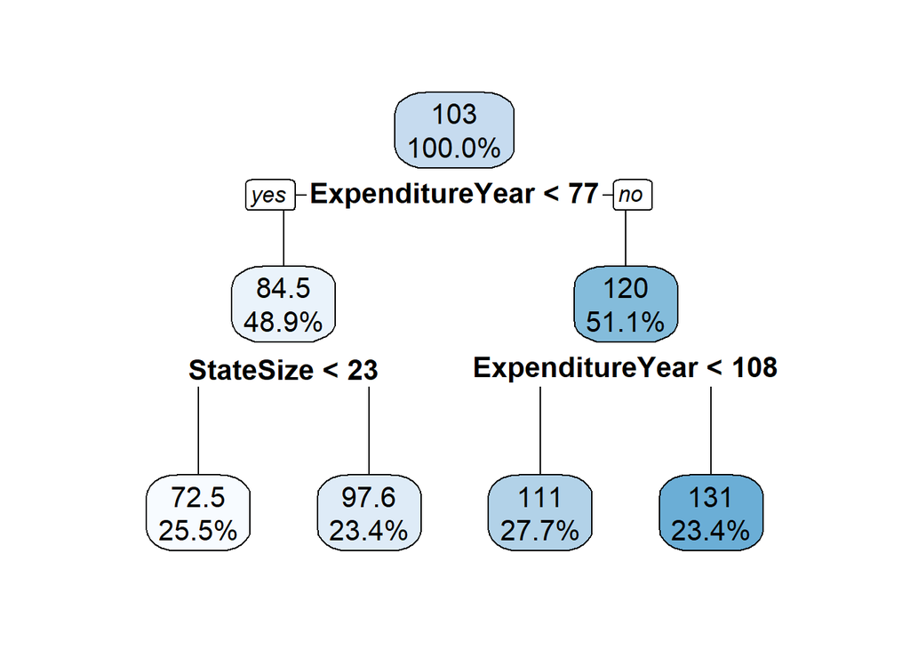

```r
# Q4
rpart.plot(m.rpart, digits = 3, fallen.leaves = TRUE,tweak=1.3,)
```

# Q 4+5: When the expenditure is less than 77 and the population is less than 23, the crime rate is on average 72.5 and this accounts for a total of 25.5 % of the observations. When the expenditure is less than 77 but the population is greater than 23 than the crime rate is 97.6 on average and this account for 23.4% of the observaitons. When the expenditure is greater than 77 but less than 108, the crime rate is 111 on average, and this account for 27.7% of the observations. Lastly, when the expenditure is greater than 77 and 108, than this accounts for the greatest average crime rate (131) of the highest 23.4% observations.

# 6: four of the six predictor variables were excluded from the regression tree. Only state size and expenditure per year were included. The regression tree is constructed balancing complexity and accuracy. Increasing the number of predictor variables will increase the accuracy but also increase the complexity. The best tree has a high level of accuracy and a low level of complexity. Predictor variables will not be added unless they add significant accuracy. Adding too many variables will cause over fitting, and won’t be accurate when compared to other datasets.

```r
#7
crimedata10 <- read.csv("crimedata10.csv")
summary(crimedata10)
```

```
##      Youth         Education     ExpenditureYear   LabourForce
##  Min.   :120.0   Min.   :10.10   Min.   : 41.00   Min.   :497.0
##  1st Qu.:134.0   1st Qu.:11.55   1st Qu.: 58.50   1st Qu.:538.0
##  Median :139.0   Median :12.40   Median : 73.00   Median :563.0
##  Mean   :140.5   Mean   :12.40   Mean   : 80.23   Mean   :565.5
##  3rd Qu.:151.5   3rd Qu.:13.25   3rd Qu.: 97.00   3rd Qu.:599.0
##  Max.   :164.0   Max.   :15.20   Max.   :157.00   Max.   :641.0
##      Males          MoreMales        StateSize     YouthUnemployment
##  Min.   : 935.0   Min.   :0.0000   Min.   :  3.0   Min.   : 71.00
##  1st Qu.: 969.5   1st Qu.:0.0000   1st Qu.: 11.0   1st Qu.: 82.00
##  Median : 983.0   Median :0.0000   Median : 25.0   Median : 93.00
##  Mean   : 986.9   Mean   :0.2128   Mean   : 37.7   Mean   : 97.45
##  3rd Qu.: 994.0   3rd Qu.:0.0000   3rd Qu.: 43.0   3rd Qu.:108.50
##  Max.   :1079.0   Max.   :1.0000   Max.   :180.0   Max.   :143.00
##  MatureUnemployment HighYouthUnemploy      Wage         BelowWage
##  Min.   :15.00      Min.   :0.0000    Min.   :359.0   Min.   :126.0
##  1st Qu.:28.00      1st Qu.:0.0000    1st Qu.:530.0   1st Qu.:165.0
##  Median :34.00      Median :0.0000    Median :615.0   Median :182.0
##  Mean   :33.36      Mean   :0.4043    Mean   :594.6   Mean   :193.0
##  3rd Qu.:39.00      3rd Qu.:1.0000    3rd Qu.:659.5   3rd Qu.:229.5
##  Max.   :59.00      Max.   :1.0000    Max.   :748.0   Max.   :257.0
##     Southern        CrimeRate
##  Min.   :0.0000   Min.   : 26.50
##  1st Qu.:0.0000   1st Qu.: 76.35
##  Median :0.0000   Median :103.50
##  Mean   :0.3404   Mean   :102.07
##  3rd Qu.:1.0000   3rd Qu.:130.25
##  Max.   :1.0000   Max.   :178.20
```

```r
p.rpart <- predict(m.rpart, crimedata10) #using m.rpart to predict crime in crimedata10
p.rpart
```

```
##         1         2         3         4         5         6         7         8
##  72.46667  72.46667  97.61818  72.46667 111.30769  97.61818  72.46667  72.46667
##         9        10        11        12        13        14        15        16
##  72.46667  72.46667  72.46667 111.30769  97.61818 131.05455  97.61818  72.46667
##        17        18        19        20        21        22        23        24
##  97.61818 131.05455 111.30769  97.61818  97.61818  97.61818  97.61818  97.61818
##        25        26        27        28        29        30        31        32
##  97.61818 111.30769  97.61818  72.46667 111.30769 131.05455 111.30769 111.30769
##        33        34        35        36        37        38        39        40
##  72.46667 111.30769 131.05455  97.61818  97.61818 111.30769  72.46667 111.30769
##        41        42        43        44        45        46        47
## 111.30769 111.30769 131.05455 111.30769 131.05455 131.05455 131.05455
```

```r
# 8
cor(p.rpart, crimedata10["CrimeRate"],method="pearson") # displays the correlation of the prediction
```

```
##      CrimeRate
## [1,]  0.585602
```